# Risk Factor Analysis

## Outcome Variable

**Outcome Variable:** ever_wasted

## Predictor Variables

**Intervention Variable:** meducyrs

**Adjustment Set:**

- arm
- W_mage
- feducyrs
- hhwealth_quart
- W_mhtcm
- W_mwtkg
- W_mbmi
- W_gagebrth
- W_birthwt
- W_birthlen
- single
- impsan
- delta_W_mage
- delta_feducyrs
- delta_hhwealth_quart
- delta_W_mhtcm
- delta_W_mwtkg
- delta_W_mbmi
- delta_W_gagebrth
- delta_W_birthwt
- delta_W_birthlen
- delta_single
- delta_impsan

## Stratifying Variables

The analysis was stratified on these variable(s):

- agecat
- studyid
- country

## Data Summary

| agecat | studyid | country | meducyrs | ever_wasted | n_cell | n |
| --- | --- | --- | --- | --- | --- | --- |
| 0-24 months | CMC-V-BCS-2002 | INDIA | High | 0 | 69 | 373 |
| 0-24 months | CMC-V-BCS-2002 | INDIA | High | 1 | 89 | 373 |
| 0-24 months | CMC-V-BCS-2002 | INDIA | Low | 0 | 38 | 373 |
| 0-24 months | CMC-V-BCS-2002 | INDIA | Low | 1 | 68 | 373 |
| 0-24 months | CMC-V-BCS-2002 | INDIA | Medium | 0 | 38 | 373 |
| 0-24 months | CMC-V-BCS-2002 | INDIA | Medium | 1 | 71 | 373 |
| 0-24 months | COHORTS | GUATEMALA | High | 0 | 218 | 1322 |
| 0-24 months | COHORTS | GUATEMALA | High | 1 | 62 | 1322 |
| 0-24 months | COHORTS | GUATEMALA | Low | 0 | 465 | 1322 |
| 0-24 months | COHORTS | GUATEMALA | Low | 1 | 162 | 1322 |
| 0-24 months | COHORTS | GUATEMALA | Medium | 0 | 300 | 1322 |
| 0-24 months | COHORTS | GUATEMALA | Medium | 1 | 115 | 1322 |
| 0-24 months | COHORTS | INDIA | High | 0 | 596 | 5844 |
| 0-24 months | COHORTS | INDIA | High | 1 | 197 | 5844 |
| 0-24 months | COHORTS | INDIA | Low | 0 | 1175 | 5844 |
| 0-24 months | COHORTS | INDIA | Low | 1 | 776 | 5844 |
| 0-24 months | COHORTS | INDIA | Medium | 0 | 2127 | 5844 |
| 0-24 months | COHORTS | INDIA | Medium | 1 | 973 | 5844 |
| 0-24 months | COHORTS | PHILIPPINES | High | 0 | 727 | 3045 |
| 0-24 months | COHORTS | PHILIPPINES | High | 1 | 441 | 3045 |
| 0-24 months | COHORTS | PHILIPPINES | Low | 0 | 496 | 3045 |
| 0-24 months | COHORTS | PHILIPPINES | Low | 1 | 405 | 3045 |
| 0-24 months | COHORTS | PHILIPPINES | Medium | 0 | 593 | 3045 |
| 0-24 months | COHORTS | PHILIPPINES | Medium | 1 | 383 | 3045 |
| 0-24 months | EE | PAKISTAN | High | 0 | 7 | 377 |
| 0-24 months | EE | PAKISTAN | High | 1 | 8 | 377 |
| 0-24 months | EE | PAKISTAN | Low | 0 | 129 | 377 |
| 0-24 months | EE | PAKISTAN | Low | 1 | 200 | 377 |
| 0-24 months | EE | PAKISTAN | Medium | 0 | 18 | 377 |
| 0-24 months | EE | PAKISTAN | Medium | 1 | 15 | 377 |

[output cut: 438 more lines]

The following strata were considered:

- agecat: 0-24 months, studyid: CMC-V-BCS-2002, country: INDIA
- agecat: 0-24 months, studyid: COHORTS, country: GUATEMALA
- agecat: 0-24 months, studyid: COHORTS, country: INDIA
- agecat: 0-24 months, studyid: COHORTS, country: PHILIPPINES
- agecat: 0-24 months, studyid: EE, country: PAKISTAN
- agecat: 0-24 months, studyid: GMS-Nepal, country: NEPAL
- agecat: 0-24 months, studyid: Guatemala BSC, country: GUATEMALA
- agecat: 0-24 months, studyid: IRC, country: INDIA
- agecat: 0-24 months, studyid: JiVitA-3, country: BANGLADESH
- agecat: 0-24 months, studyid: JiVitA-4, country: BANGLADESH
- agecat: 0-24 months, studyid: LCNI-5, country: MALAWI
- agecat: 0-24 months, studyid: MAL-ED, country: BANGLADESH
- agecat: 0-24 months, studyid: MAL-ED, country: BRAZIL
- agecat: 0-24 months, studyid: MAL-ED, country: INDIA
- agecat: 0-24 months, studyid: MAL-ED, country: NEPAL
- agecat: 0-24 months, studyid: MAL-ED, country: PERU
- agecat: 0-24 months, studyid: MAL-ED, country: SOUTH AFRICA
- agecat: 0-24 months, studyid: MAL-ED, country: TANZANIA, UNITED REPUBLIC OF
- agecat: 0-24 months, studyid: NIH-Birth, country: BANGLADESH
- agecat: 0-24 months, studyid: NIH-Crypto, country: BANGLADESH
- agecat: 0-24 months, studyid: PROBIT, country: BELARUS
- agecat: 0-24 months, studyid: PROVIDE, country: BANGLADESH
- agecat: 0-24 months, studyid: SAS-CompFeed, country: INDIA
- agecat: 0-24 months, studyid: SAS-FoodSuppl, country: INDIA
- agecat: 0-24 months, studyid: TanzaniaChild2, country: TANZANIA, UNITED REPUBLIC OF
- agecat: 0-24 months, studyid: ZVITAMBO, country: ZIMBABWE
- agecat: 0-6 months, studyid: CMC-V-BCS-2002, country: INDIA
- agecat: 0-6 months, studyid: COHORTS, country: GUATEMALA
- agecat: 0-6 months, studyid: COHORTS, country: INDIA
- agecat: 0-6 months, studyid: COHORTS, country: PHILIPPINES
- agecat: 0-6 months, studyid: EE, country: PAKISTAN
- agecat: 0-6 months, studyid: GMS-Nepal, country: NEPAL
- agecat: 0-6 months, studyid: Guatemala BSC, country: GUATEMALA
- agecat: 0-6 months, studyid: IRC, country: INDIA
- agecat: 0-6 months, studyid: JiVitA-3, country: BANGLADESH
- agecat: 0-6 months, studyid: JiVitA-4, country: BANGLADESH
- agecat: 0-6 months, studyid: LCNI-5, country: MALAWI
- agecat: 0-6 months, studyid: MAL-ED, country: BANGLADESH
- agecat: 0-6 months, studyid: MAL-ED, country: BRAZIL
- agecat: 0-6 months, studyid: MAL-ED, country: INDIA
- agecat: 0-6 months, studyid: MAL-ED, country: NEPAL
- agecat: 0-6 months, studyid: MAL-ED, country: PERU
- agecat: 0-6 months, studyid: MAL-ED, country: SOUTH AFRICA
- agecat: 0-6 months, studyid: MAL-ED, country: TANZANIA, UNITED REPUBLIC OF
- agecat: 0-6 months, studyid: NIH-Birth, country: BANGLADESH
- agecat: 0-6 months, studyid: NIH-Crypto, country: BANGLADESH
- agecat: 0-6 months, studyid: PROBIT, country: BELARUS
- agecat: 0-6 months, studyid: PROVIDE, country: BANGLADESH
- agecat: 0-6 months, studyid: SAS-CompFeed, country: INDIA
- agecat: 0-6 months, studyid: SAS-FoodSuppl, country: INDIA
- agecat: 0-6 months, studyid: TanzaniaChild2, country: TANZANIA, UNITED REPUBLIC OF
- agecat: 0-6 months, studyid: ZVITAMBO, country: ZIMBABWE
- agecat: 6-24 months, studyid: CMC-V-BCS-2002, country: INDIA
- agecat: 6-24 months, studyid: COHORTS, country: GUATEMALA
- agecat: 6-24 months, studyid: COHORTS, country: INDIA
- agecat: 6-24 months, studyid: COHORTS, country: PHILIPPINES
- agecat: 6-24 months, studyid: EE, country: PAKISTAN
- agecat: 6-24 months, studyid: GMS-Nepal, country: NEPAL
- agecat: 6-24 months, studyid: Guatemala BSC, country: GUATEMALA
- agecat: 6-24 months, studyid: IRC, country: INDIA
- agecat: 6-24 months, studyid: JiVitA-3, country: BANGLADESH
- agecat: 6-24 months, studyid: JiVitA-4, country: BANGLADESH
- agecat: 6-24 months, studyid: LCNI-5, country: MALAWI
- agecat: 6-24 months, studyid: MAL-ED, country: BANGLADESH
- agecat: 6-24 months, studyid: MAL-ED, country: BRAZIL
- agecat: 6-24 months, studyid: MAL-ED, country: INDIA
- agecat: 6-24 months, studyid: MAL-ED, country: NEPAL
- agecat: 6-24 months, studyid: MAL-ED, country: PERU
- agecat: 6-24 months, studyid: MAL-ED, country: SOUTH AFRICA
- agecat: 6-24 months, studyid: MAL-ED, country: TANZANIA, UNITED REPUBLIC OF
- agecat: 6-24 months, studyid: NIH-Birth, country: BANGLADESH
- agecat: 6-24 months, studyid: NIH-Crypto, country: BANGLADESH
- agecat: 6-24 months, studyid: PROBIT, country: BELARUS
- agecat: 6-24 months, studyid: PROVIDE, country: BANGLADESH
- agecat: 6-24 months, studyid: SAS-CompFeed, country: INDIA
- agecat: 6-24 months, studyid: SAS-FoodSuppl, country: INDIA
- agecat: 6-24 months, studyid: TanzaniaChild2, country: TANZANIA, UNITED REPUBLIC OF
- agecat: 6-24 months, studyid: ZVITAMBO, country: ZIMBABWE

### Dropped Strata

Some strata were dropped due to rare outcomes:

- agecat: 0-24 months, studyid: MAL-ED, country: BRAZIL
- agecat: 0-24 months, studyid: MAL-ED, country: PERU
- agecat: 0-24 months, studyid: MAL-ED, country: TANZANIA, UNITED REPUBLIC OF
- agecat: 0-6 months, studyid: EE, country: PAKISTAN
- agecat: 0-6 months, studyid: Guatemala BSC, country: GUATEMALA
- agecat: 0-6 months, studyid: LCNI-5, country: MALAWI
- agecat: 0-6 months, studyid: MAL-ED, country: BRAZIL
- agecat: 0-6 months, studyid: MAL-ED, country: PERU
- agecat: 0-6 months, studyid: MAL-ED, country: TANZANIA, UNITED REPUBLIC OF
- agecat: 0-6 months, studyid: SAS-FoodSuppl, country: INDIA
- agecat: 6-24 months, studyid: Guatemala BSC, country: GUATEMALA
- agecat: 6-24 months, studyid: MAL-ED, country: BRAZIL
- agecat: 6-24 months, studyid: MAL-ED, country: PERU
- agecat: 6-24 months, studyid: MAL-ED, country: TANZANIA, UNITED REPUBLIC OF

## Methods Detail

We're interested in the causal parameters $E[Y_a]$ for all values of $a \in \mathcal{A}$. These parameters represent the mean outcome if, possibly contrary to fact, we intervened to set all units to have $A=a$. Under the randomization and positivity assumptions, these are identified by the statistical parameters $\psi_a=E_W[E_{Y|A,W}(Y|A=a,W)]$. In addition, we're interested in the mean of $Y$, $E[Y]$ under no intervention (the observed mean). We will estimate these parameters by using SuperLearner to fit the relevant likelihood factors -- $E_{Y|A,W}(Y|A=a,W)$ and $p(A=a|W)$, and then updating our likelihood fit using a joint TMLE.

For unadjusted analyses ($W=\{\}$), initial likelihoods were estimated using Lrnr_glm to estimate the simple $E(Y|A)$ and Lrnr_mean to estimate $p(A)$. For adjusted analyses, a small library containing Lrnr_glmnet, Lrnr_xgboost, and Lrnr_mean was used.

Having estimated these parameters, we will then use the delta method to estimate relative risks and attributable risks relative to a prespecified baseline level of $A$.

# Results Detail

## Results Plots

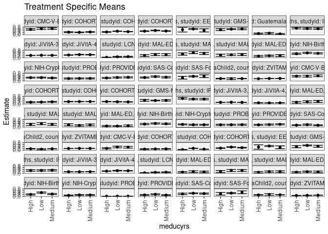

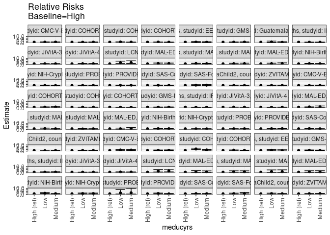

[figure not shown]

[figure not shown]

## Results Table

### Parameter: TSM

| agecat | studyid | country | intervention_level | baseline_level | estimate | ci_lower | ci_upper |
| --- | --- | --- | --- | --- | --- | --- | --- |
| 0-24 months | CMC-V-BCS-2002 | INDIA | High | NA | 0.5606668 | 0.4822717 | 0.6390618 |
| 0-24 months | CMC-V-BCS-2002 | INDIA | Low | NA | 0.6450606 | 0.5532013 | 0.7369199 |
| 0-24 months | CMC-V-BCS-2002 | INDIA | Medium | NA | 0.6558134 | 0.5650537 | 0.7465730 |
| 0-24 months | COHORTS | GUATEMALA | High | NA | 0.2614598 | 0.2130722 | 0.3098474 |
| 0-24 months | COHORTS | GUATEMALA | Low | NA | 0.2432754 | 0.2122673 | 0.2742835 |
| 0-24 months | COHORTS | GUATEMALA | Medium | NA | 0.2803237 | 0.2396111 | 0.3210363 |
| 0-24 months | COHORTS | INDIA | High | NA | 0.2825836 | 0.2490576 | 0.3161097 |
| 0-24 months | COHORTS | INDIA | Low | NA | 0.3652657 | 0.3427207 | 0.3878106 |
| 0-24 months | COHORTS | INDIA | Medium | NA | 0.3185121 | 0.3025765 | 0.3344477 |
| 0-24 months | COHORTS | PHILIPPINES | High | NA | 0.3733962 | 0.3404832 | 0.4063093 |
| 0-24 months | COHORTS | PHILIPPINES | Low | NA | 0.4429513 | 0.4051041 | 0.4807985 |
| 0-24 months | COHORTS | PHILIPPINES | Medium | NA | 0.3863501 | 0.3545920 | 0.4181082 |
| 0-24 months | EE | PAKISTAN | High | NA | 0.5333333 | 0.2805305 | 0.7861362 |
| 0-24 months | EE | PAKISTAN | Low | NA | 0.6079027 | 0.5550776 | 0.6607279 |
| 0-24 months | EE | PAKISTAN | Medium | NA | 0.4545455 | 0.2844331 | 0.6246578 |
| 0-24 months | GMS-Nepal | NEPAL | High | NA | 0.5390325 | 0.4340129 | 0.6440521 |
| 0-24 months | GMS-Nepal | NEPAL | Low | NA | 0.5915786 | 0.5484853 | 0.6346718 |
| 0-24 months | GMS-Nepal | NEPAL | Medium | NA | 0.6165948 | 0.5307314 | 0.7024583 |
| 0-24 months | Guatemala BSC | GUATEMALA | High | NA | 0.1101695 | 0.0535765 | 0.1667625 |
| 0-24 months | Guatemala BSC | GUATEMALA | Low | NA | 0.1447368 | 0.0654954 | 0.2239782 |
| 0-24 months | Guatemala BSC | GUATEMALA | Medium | NA | 0.0681818 | 0.0154251 | 0.1209386 |
| 0-24 months | IRC | INDIA | High | NA | 0.6934266 | 0.6120333 | 0.7748199 |
| 0-24 months | IRC | INDIA | Low | NA | 0.6596998 | 0.5882377 | 0.7311619 |
| 0-24 months | IRC | INDIA | Medium | NA | 0.6393214 | 0.5611018 | 0.7175409 |
| 0-24 months | JiVitA-3 | BANGLADESH | High | NA | 0.2452535 | 0.2327086 | 0.2577984 |
| 0-24 months | JiVitA-3 | BANGLADESH | Low | NA | 0.2595485 | 0.2474947 | 0.2716023 |
| 0-24 months | JiVitA-3 | BANGLADESH | Medium | NA | 0.2555407 | 0.2425702 | 0.2685111 |
| 0-24 months | JiVitA-4 | BANGLADESH | High | NA | 0.2888381 | 0.2623509 | 0.3153253 |
| 0-24 months | JiVitA-4 | BANGLADESH | Low | NA | 0.3343707 | 0.3056670 | 0.3630744 |
| 0-24 months | JiVitA-4 | BANGLADESH | Medium | NA | 0.3243241 | 0.2979516 | 0.3506967 |

[output cut: 162 more lines]

### Parameter: E(Y)

| agecat | studyid | country | intervention_level | baseline_level | estimate | ci_lower | ci_upper |
| --- | --- | --- | --- | --- | --- | --- | --- |
| 0-24 months | CMC-V-BCS-2002 | INDIA | NA | NA | 0.6112601 | 0.5617242 | 0.6607959 |
| 0-24 months | COHORTS | GUATEMALA | NA | NA | 0.2564297 | 0.2328823 | 0.2799770 |
| 0-24 months | COHORTS | INDIA | NA | NA | 0.3329911 | 0.3209071 | 0.3450751 |
| 0-24 months | COHORTS | PHILIPPINES | NA | NA | 0.4036125 | 0.3861835 | 0.4210415 |
| 0-24 months | EE | PAKISTAN | NA | NA | 0.5915119 | 0.5418269 | 0.6411970 |
| 0-24 months | GMS-Nepal | NEPAL | NA | NA | 0.5900439 | 0.5531320 | 0.6269559 |
| 0-24 months | Guatemala BSC | GUATEMALA | NA | NA | 0.1063830 | 0.0703329 | 0.1424331 |
| 0-24 months | IRC | INDIA | NA | NA | 0.6560976 | 0.6100625 | 0.7021326 |
| 0-24 months | JiVitA-3 | BANGLADESH | NA | NA | 0.2580418 | 0.2515722 | 0.2645113 |
| 0-24 months | JiVitA-4 | BANGLADESH | NA | NA | 0.3105166 | 0.2961054 | 0.3249278 |
| 0-24 months | LCNI-5 | MALAWI | NA | NA | 0.0798526 | 0.0612199 | 0.0984853 |
| 0-24 months | MAL-ED | BANGLADESH | NA | NA | 0.3004695 | 0.2387555 | 0.3621835 |
| 0-24 months | MAL-ED | INDIA | NA | NA | 0.4727273 | 0.4066048 | 0.5388497 |
| 0-24 months | MAL-ED | NEPAL | NA | NA | 0.3111111 | 0.2504855 | 0.3717368 |
| 0-24 months | MAL-ED | SOUTH AFRICA | NA | NA | 0.2051282 | 0.1602507 | 0.2500058 |
| 0-24 months | NIH-Birth | BANGLADESH | NA | NA | 0.4775641 | 0.4383415 | 0.5167867 |
| 0-24 months | NIH-Crypto | BANGLADESH | NA | NA | 0.3298153 | 0.2963239 | 0.3633067 |
| 0-24 months | PROBIT | BELARUS | NA | NA | 0.2554148 | 0.1971257 | 0.3137039 |
| 0-24 months | PROVIDE | BANGLADESH | NA | NA | 0.3514286 | 0.3160364 | 0.3868207 |
| 0-24 months | SAS-CompFeed | INDIA | NA | NA | 0.4150694 | 0.3581204 | 0.4720184 |
| 0-24 months | SAS-FoodSuppl | INDIA | NA | NA | 0.4712919 | 0.4233811 | 0.5192026 |
| 0-24 months | TanzaniaChild2 | TANZANIA, UNITED REPUBLIC OF | NA | NA | 0.2367980 | 0.2197367 | 0.2538593 |
| 0-24 months | ZVITAMBO | ZIMBABWE | NA | NA | 0.2366078 | 0.2295489 | 0.2436667 |
| 0-6 months | CMC-V-BCS-2002 | INDIA | NA | NA | 0.5163043 | 0.4651769 | 0.5674318 |
| 0-6 months | COHORTS | GUATEMALA | NA | NA | 0.2007612 | 0.1765324 | 0.2249900 |
| 0-6 months | COHORTS | INDIA | NA | NA | 0.2511554 | 0.2398221 | 0.2624886 |
| 0-6 months | COHORTS | PHILIPPINES | NA | NA | 0.2355453 | 0.2204685 | 0.2506222 |
| 0-6 months | GMS-Nepal | NEPAL | NA | NA | 0.3762811 | 0.3399226 | 0.4126397 |
| 0-6 months | IRC | INDIA | NA | NA | 0.5439024 | 0.4956326 | 0.5921723 |
| 0-6 months | JiVitA-3 | BANGLADESH | NA | NA | 0.1762162 | 0.1705869 | 0.1818456 |
| 0-6 months | JiVitA-4 | BANGLADESH | NA | NA | 0.1079378 | 0.0980978 | 0.1177778 |
| 0-6 months | MAL-ED | BANGLADESH | NA | NA | 0.2253521 | 0.1691098 | 0.2815944 |
| 0-6 months | MAL-ED | INDIA | NA | NA | 0.3181818 | 0.2564942 | 0.3798694 |
| 0-6 months | MAL-ED | NEPAL | NA | NA | 0.2000000 | 0.1476178 | 0.2523822 |
| 0-6 months | MAL-ED | SOUTH AFRICA | NA | NA | 0.1121795 | 0.0771053 | 0.1472536 |
| 0-6 months | NIH-Birth | BANGLADESH | NA | NA | 0.3569132 | 0.3192325 | 0.3945938 |
| 0-6 months | NIH-Crypto | BANGLADESH | NA | NA | 0.2572559 | 0.2261171 | 0.2883948 |
| 0-6 months | PROBIT | BELARUS | NA | NA | 0.2500148 | 0.1915461 | 0.3084835 |
| 0-6 months | PROVIDE | BANGLADESH | NA | NA | 0.2585714 | 0.2261125 | 0.2910304 |
| 0-6 months | SAS-CompFeed | INDIA | NA | NA | 0.2199336 | 0.1753445 | 0.2645227 |
| 0-6 months | TanzaniaChild2 | TANZANIA, UNITED REPUBLIC OF | NA | NA | 0.1395641 | 0.1256566 | 0.1534717 |
| 0-6 months | ZVITAMBO | ZIMBABWE | NA | NA | 0.1810164 | 0.1745999 | 0.1874330 |
| 6-24 months | CMC-V-BCS-2002 | INDIA | NA | NA | 0.2654155 | 0.2205451 | 0.3102860 |
| 6-24 months | COHORTS | GUATEMALA | NA | NA | 0.1277129 | 0.1088047 | 0.1466210 |
| 6-24 months | COHORTS | INDIA | NA | NA | 0.1266654 | 0.1178579 | 0.1354730 |
| 6-24 months | COHORTS | PHILIPPINES | NA | NA | 0.2666429 | 0.2502871 | 0.2829988 |
| 6-24 months | EE | PAKISTAN | NA | NA | 0.4258760 | 0.3754921 | 0.4762599 |
| 6-24 months | GMS-Nepal | NEPAL | NA | NA | 0.4735945 | 0.4331684 | 0.5140207 |
| 6-24 months | IRC | INDIA | NA | NA | 0.3097561 | 0.2649438 | 0.3545684 |
| 6-24 months | JiVitA-3 | BANGLADESH | NA | NA | 0.1638889 | 0.1577625 | 0.1700152 |
| 6-24 months | JiVitA-4 | BANGLADESH | NA | NA | 0.2475997 | 0.2340658 | 0.2611337 |
| 6-24 months | LCNI-5 | MALAWI | NA | NA | 0.0772105 | 0.0587369 | 0.0956840 |
| 6-24 months | MAL-ED | BANGLADESH | NA | NA | 0.1384615 | 0.0898601 | 0.1870630 |
| 6-24 months | MAL-ED | INDIA | NA | NA | 0.2657005 | 0.2053824 | 0.3260185 |
| 6-24 months | MAL-ED | NEPAL | NA | NA | 0.1545455 | 0.1066715 | 0.2024194 |
| 6-24 months | MAL-ED | SOUTH AFRICA | NA | NA | 0.1428571 | 0.1001583 | 0.1855560 |
| 6-24 months | NIH-Birth | BANGLADESH | NA | NA | 0.2933579 | 0.2549918 | 0.3317241 |
| 6-24 months | NIH-Crypto | BANGLADESH | NA | NA | 0.1315068 | 0.1069744 | 0.1560393 |
| 6-24 months | PROBIT | BELARUS | NA | NA | 0.0083745 | 0.0044130 | 0.0123360 |
| 6-24 months | PROVIDE | BANGLADESH | NA | NA | 0.1609756 | 0.1319065 | 0.1900447 |
| 6-24 months | SAS-CompFeed | INDIA | NA | NA | 0.3059755 | 0.2638053 | 0.3481458 |
| 6-24 months | SAS-FoodSuppl | INDIA | NA | NA | 0.3557214 | 0.3088651 | 0.4025777 |
| 6-24 months | TanzaniaChild2 | TANZANIA, UNITED REPUBLIC OF | NA | NA | 0.1606166 | 0.1445647 | 0.1766685 |
| 6-24 months | ZVITAMBO | ZIMBABWE | NA | NA | 0.0959259 | 0.0903717 | 0.1014802 |

### Parameter: RR

| agecat | studyid | country | intervention_level | baseline_level | estimate | ci_lower | ci_upper |
| --- | --- | --- | --- | --- | --- | --- | --- |
| 0-24 months | CMC-V-BCS-2002 | INDIA | High | High | 1.0000000 | 1.0000000 | 1.0000000 |
| 0-24 months | CMC-V-BCS-2002 | INDIA | Low | High | 1.1505240 | 0.9424288 | 1.4045682 |
| 0-24 months | CMC-V-BCS-2002 | INDIA | Medium | High | 1.1697025 | 0.9608427 | 1.4239626 |
| 0-24 months | COHORTS | GUATEMALA | High | High | 1.0000000 | 1.0000000 | 1.0000000 |
| 0-24 months | COHORTS | GUATEMALA | Low | High | 0.9304505 | 0.7533284 | 1.1492175 |
| 0-24 months | COHORTS | GUATEMALA | Medium | High | 1.0721485 | 0.8577294 | 1.3401692 |
| 0-24 months | COHORTS | INDIA | High | High | 1.0000000 | 1.0000000 | 1.0000000 |
| 0-24 months | COHORTS | INDIA | Low | High | 1.2925930 | 1.1348215 | 1.4722991 |
| 0-24 months | COHORTS | INDIA | Medium | High | 1.1271428 | 0.9954769 | 1.2762234 |
| 0-24 months | COHORTS | PHILIPPINES | High | High | 1.0000000 | 1.0000000 | 1.0000000 |
| 0-24 months | COHORTS | PHILIPPINES | Low | High | 1.1862769 | 1.0523005 | 1.3373108 |
| 0-24 months | COHORTS | PHILIPPINES | Medium | High | 1.0346920 | 0.9211968 | 1.1621704 |
| 0-24 months | EE | PAKISTAN | High | High | 1.0000000 | 1.0000000 | 1.0000000 |
| 0-24 months | EE | PAKISTAN | Low | High | 1.1398176 | 0.7039580 | 1.8455421 |
| 0-24 months | EE | PAKISTAN | Medium | High | 0.8522727 | 0.4658985 | 1.5590708 |
| 0-24 months | GMS-Nepal | NEPAL | High | High | 1.0000000 | 1.0000000 | 1.0000000 |
| 0-24 months | GMS-Nepal | NEPAL | Low | High | 1.0974822 | 0.8941239 | 1.3470921 |
| 0-24 months | GMS-Nepal | NEPAL | Medium | High | 1.1438918 | 0.9027119 | 1.4495082 |
| 0-24 months | Guatemala BSC | GUATEMALA | High | High | 1.0000000 | 1.0000000 | 1.0000000 |
| 0-24 months | Guatemala BSC | GUATEMALA | Low | High | 1.3137652 | 0.6201163 | 2.7833150 |
| 0-24 months | Guatemala BSC | GUATEMALA | Medium | High | 0.6188811 | 0.2444853 | 1.5666127 |
| 0-24 months | IRC | INDIA | High | High | 1.0000000 | 1.0000000 | 1.0000000 |
| 0-24 months | IRC | INDIA | Low | High | 0.9513620 | 0.8142741 | 1.1115296 |
| 0-24 months | IRC | INDIA | Medium | High | 0.9219741 | 0.7793802 | 1.0906567 |
| 0-24 months | JiVitA-3 | BANGLADESH | High | High | 1.0000000 | 1.0000000 | 1.0000000 |
| 0-24 months | JiVitA-3 | BANGLADESH | Low | High | 1.0582866 | 0.9914612 | 1.1296162 |
| 0-24 months | JiVitA-3 | BANGLADESH | Medium | High | 1.0419451 | 0.9727941 | 1.1160116 |
| 0-24 months | JiVitA-4 | BANGLADESH | High | High | 1.0000000 | 1.0000000 | 1.0000000 |
| 0-24 months | JiVitA-4 | BANGLADESH | Low | High | 1.1576406 | 1.0226052 | 1.3105075 |
| 0-24 months | JiVitA-4 | BANGLADESH | Medium | High | 1.1228580 | 0.9932913 | 1.2693256 |

[output cut: 162 more lines]

### Parameter: PAR

| agecat | studyid | country | intervention_level | baseline_level | estimate | ci_lower | ci_upper |
| --- | --- | --- | --- | --- | --- | --- | --- |
| 0-24 months | CMC-V-BCS-2002 | INDIA | High | NA | 0.0505933 | -0.0085883 | 0.1097749 |
| 0-24 months | COHORTS | GUATEMALA | High | NA | -0.0050301 | -0.0473519 | 0.0372917 |
| 0-24 months | COHORTS | INDIA | High | NA | 0.0504075 | 0.0183736 | 0.0824413 |
| 0-24 months | COHORTS | PHILIPPINES | High | NA | 0.0302163 | 0.0017297 | 0.0587028 |
| 0-24 months | EE | PAKISTAN | High | NA | 0.0581786 | -0.1893941 | 0.3057514 |
| 0-24 months | GMS-Nepal | NEPAL | High | NA | 0.0510114 | -0.0466108 | 0.1486337 |
| 0-24 months | Guatemala BSC | GUATEMALA | High | NA | -0.0037865 | -0.0464720 | 0.0388989 |
| 0-24 months | IRC | INDIA | High | NA | -0.0373291 | -0.1042026 | 0.0295445 |
| 0-24 months | JiVitA-3 | BANGLADESH | High | NA | 0.0127883 | 0.0016659 | 0.0239106 |
| 0-24 months | JiVitA-4 | BANGLADESH | High | NA | 0.0216785 | -0.0019685 | 0.0453256 |
| 0-24 months | LCNI-5 | MALAWI | High | NA | 0.0434032 | 0.0219768 | 0.0648296 |
| 0-24 months | MAL-ED | BANGLADESH | High | NA | 0.0675101 | -0.0128694 | 0.1478896 |
| 0-24 months | MAL-ED | INDIA | High | NA | 0.0744076 | -0.0307659 | 0.1795812 |
| 0-24 months | MAL-ED | NEPAL | High | NA | 0.0488144 | -0.0587761 | 0.1564049 |
| 0-24 months | MAL-ED | SOUTH AFRICA | High | NA | 0.0401773 | -0.0254812 | 0.1058358 |
| 0-24 months | NIH-Birth | BANGLADESH | High | NA | 0.0483049 | -0.0072216 | 0.1038314 |
| 0-24 months | NIH-Crypto | BANGLADESH | High | NA | -0.0102045 | -0.0497051 | 0.0292962 |
| 0-24 months | PROBIT | BELARUS | High | NA | 0.0148524 | 0.0037299 | 0.0259749 |
| 0-24 months | PROVIDE | BANGLADESH | High | NA | 0.0424335 | -0.0064821 | 0.0913490 |
| 0-24 months | SAS-CompFeed | INDIA | High | NA | 0.0611272 | 0.0136357 | 0.1086186 |
| 0-24 months | SAS-FoodSuppl | INDIA | High | NA | 0.1398129 | -0.0036853 | 0.2833110 |
| 0-24 months | TanzaniaChild2 | TANZANIA, UNITED REPUBLIC OF | High | NA | -0.0004877 | -0.0295157 | 0.0285403 |
| 0-24 months | ZVITAMBO | ZIMBABWE | High | NA | 0.0118484 | 0.0061128 | 0.0175841 |
| 0-6 months | CMC-V-BCS-2002 | INDIA | High | NA | 0.0193908 | -0.0415470 | 0.0803285 |
| 0-6 months | COHORTS | GUATEMALA | High | NA | 0.0176083 | -0.0299031 | 0.0651197 |
| 0-6 months | COHORTS | INDIA | High | NA | 0.0067862 | -0.0174472 | 0.0310195 |
| 0-6 months | COHORTS | PHILIPPINES | High | NA | -0.0132179 | -0.0312554 | 0.0048196 |
| 0-6 months | GMS-Nepal | NEPAL | High | NA | -0.0063330 | -0.0930496 | 0.0803837 |
| 0-6 months | IRC | INDIA | High | NA | -0.0502208 | -0.1169171 | 0.0164756 |
| 0-6 months | JiVitA-3 | BANGLADESH | High | NA | 0.0037015 | -0.0055005 | 0.0129035 |
| 0-6 months | JiVitA-4 | BANGLADESH | High | NA | -0.0058881 | -0.0195527 | 0.0077765 |
| 0-6 months | MAL-ED | BANGLADESH | High | NA | 0.0544172 | -0.0184669 | 0.1273013 |
| 0-6 months | MAL-ED | INDIA | High | NA | 0.0426510 | -0.0540848 | 0.1393868 |
| 0-6 months | MAL-ED | NEPAL | High | NA | -0.0356303 | -0.1351113 | 0.0638507 |
| 0-6 months | MAL-ED | SOUTH AFRICA | High | NA | 0.0097257 | -0.0435753 | 0.0630268 |
| 0-6 months | NIH-Birth | BANGLADESH | High | NA | 0.0381020 | -0.0209000 | 0.0971040 |
| 0-6 months | NIH-Crypto | BANGLADESH | High | NA | -0.0213849 | -0.0637042 | 0.0209345 |
| 0-6 months | PROBIT | BELARUS | High | NA | 0.0096129 | -0.0014931 | 0.0207190 |
| 0-6 months | PROVIDE | BANGLADESH | High | NA | 0.0231683 | -0.0217209 | 0.0680575 |
| 0-6 months | SAS-CompFeed | INDIA | High | NA | 0.0211893 | -0.0073765 | 0.0497551 |
| 0-6 months | TanzaniaChild2 | TANZANIA, UNITED REPUBLIC OF | High | NA | -0.0069737 | -0.0307331 | 0.0167856 |
| 0-6 months | ZVITAMBO | ZIMBABWE | High | NA | 0.0036209 | -0.0000117 | 0.0072536 |
| 6-24 months | CMC-V-BCS-2002 | INDIA | High | NA | 0.0782816 | 0.0268512 | 0.1297121 |
| 6-24 months | COHORTS | GUATEMALA | High | NA | 0.0218295 | -0.0114464 | 0.0551053 |
| 6-24 months | COHORTS | INDIA | High | NA | 0.0703087 | 0.0520952 | 0.0885221 |
| 6-24 months | COHORTS | PHILIPPINES | High | NA | 0.0513511 | 0.0224046 | 0.0802976 |
| 6-24 months | EE | PAKISTAN | High | NA | 0.0925427 | -0.1419536 | 0.3270389 |
| 6-24 months | GMS-Nepal | NEPAL | High | NA | 0.0979499 | -0.0136514 | 0.2095512 |
| 6-24 months | IRC | INDIA | High | NA | 0.0179854 | -0.0514514 | 0.0874223 |
| 6-24 months | JiVitA-3 | BANGLADESH | High | NA | 0.0070078 | -0.0063017 | 0.0203174 |
| 6-24 months | JiVitA-4 | BANGLADESH | High | NA | 0.0209807 | -0.0026311 | 0.0445926 |
| 6-24 months | LCNI-5 | MALAWI | High | NA | 0.0403565 | 0.0189058 | 0.0618071 |
| 6-24 months | MAL-ED | BANGLADESH | High | NA | 0.0257855 | -0.0361817 | 0.0877527 |
| 6-24 months | MAL-ED | INDIA | High | NA | 0.0789383 | -0.0180532 | 0.1759299 |
| 6-24 months | MAL-ED | NEPAL | High | NA | 0.0583916 | -0.0170578 | 0.1338410 |
| 6-24 months | MAL-ED | SOUTH AFRICA | High | NA | 0.0347490 | -0.0283117 | 0.0978098 |
| 6-24 months | NIH-Birth | BANGLADESH | High | NA | 0.0915961 | 0.0345268 | 0.1486654 |
| 6-24 months | NIH-Crypto | BANGLADESH | High | NA | 0.0293373 | -0.0031301 | 0.0618048 |
| 6-24 months | PROBIT | BELARUS | High | NA | 0.0046676 | 0.0009535 | 0.0083817 |
| 6-24 months | PROVIDE | BANGLADESH | High | NA | 0.0162792 | -0.0232709 | 0.0558293 |
| 6-24 months | SAS-CompFeed | INDIA | High | NA | 0.0432921 | -0.0267245 | 0.1133087 |
| 6-24 months | SAS-FoodSuppl | INDIA | High | NA | 0.0798207 | -0.0588261 | 0.2184676 |
| 6-24 months | TanzaniaChild2 | TANZANIA, UNITED REPUBLIC OF | High | NA | 0.0131662 | -0.0136948 | 0.0400271 |
| 6-24 months | ZVITAMBO | ZIMBABWE | High | NA | 0.0114576 | 0.0047497 | 0.0181655 |

### Parameter: PAF

| agecat | studyid | country | intervention_level | baseline_level | estimate | ci_lower | ci_upper |
| --- | --- | --- | --- | --- | --- | --- | --- |
| 0-24 months | CMC-V-BCS-2002 | INDIA | High | NA | 0.0827688 | -0.0198429 | 0.1750563 |
| 0-24 months | COHORTS | GUATEMALA | High | NA | -0.0196160 | -0.1987830 | 0.1327732 |
| 0-24 months | COHORTS | INDIA | High | NA | 0.1513778 | 0.0497203 | 0.2421603 |
| 0-24 months | COHORTS | PHILIPPINES | High | NA | 0.0748645 | 0.0015559 | 0.1427906 |
| 0-24 months | EE | PAKISTAN | High | NA | 0.0983558 | -0.4344899 | 0.4332743 |
| 0-24 months | GMS-Nepal | NEPAL | High | NA | 0.0864536 | -0.0951530 | 0.2379448 |
| 0-24 months | Guatemala BSC | GUATEMALA | High | NA | -0.0355932 | -0.5254587 | 0.2969634 |
| 0-24 months | IRC | INDIA | High | NA | -0.0568956 | -0.1639606 | 0.0403212 |
| 0-24 months | JiVitA-3 | BANGLADESH | High | NA | 0.0495589 | 0.0055189 | 0.0916486 |
| 0-24 months | JiVitA-4 | BANGLADESH | High | NA | 0.0698144 | -0.0092812 | 0.1427114 |
| 0-24 months | LCNI-5 | MALAWI | High | NA | 0.5435416 | 0.2296833 | 0.7295213 |
| 0-24 months | MAL-ED | BANGLADESH | High | NA | 0.2246821 | -0.0943486 | 0.4507071 |
| 0-24 months | MAL-ED | INDIA | High | NA | 0.1574008 | -0.0982677 | 0.3535516 |
| 0-24 months | MAL-ED | NEPAL | High | NA | 0.1569034 | -0.2705528 | 0.4405492 |
| 0-24 months | MAL-ED | SOUTH AFRICA | High | NA | 0.1958644 | -0.1957497 | 0.4592229 |
| 0-24 months | NIH-Birth | BANGLADESH | High | NA | 0.1011486 | -0.0230770 | 0.2102903 |
| 0-24 months | NIH-Crypto | BANGLADESH | High | NA | -0.0309399 | -0.1578640 | 0.0820709 |
| 0-24 months | PROBIT | BELARUS | High | NA | 0.0581501 | 0.0096504 | 0.1042747 |
| 0-24 months | PROVIDE | BANGLADESH | High | NA | 0.1207456 | -0.0296543 | 0.2491769 |
| 0-24 months | SAS-CompFeed | INDIA | High | NA | 0.1472697 | 0.0329219 | 0.2480969 |
| 0-24 months | SAS-FoodSuppl | INDIA | High | NA | 0.2966587 | -0.0855339 | 0.5442898 |
| 0-24 months | TanzaniaChild2 | TANZANIA, UNITED REPUBLIC OF | High | NA | -0.0020595 | -0.1324583 | 0.1133243 |
| 0-24 months | ZVITAMBO | ZIMBABWE | High | NA | 0.0500763 | 0.0255606 | 0.0739751 |
| 0-6 months | CMC-V-BCS-2002 | INDIA | High | NA | 0.0375568 | -0.0881140 | 0.1487134 |
| 0-6 months | COHORTS | GUATEMALA | High | NA | 0.0877076 | -0.1821928 | 0.2959884 |
| 0-6 months | COHORTS | INDIA | High | NA | 0.0270198 | -0.0743728 | 0.1188436 |
| 0-6 months | COHORTS | PHILIPPINES | High | NA | -0.0561162 | -0.1356151 | 0.0178174 |
| 0-6 months | GMS-Nepal | NEPAL | High | NA | -0.0168304 | -0.2754388 | 0.1893425 |
| 0-6 months | IRC | INDIA | High | NA | -0.0923342 | -0.2226181 | 0.0240665 |
| 0-6 months | JiVitA-3 | BANGLADESH | High | NA | 0.0210056 | -0.0326149 | 0.0718416 |
| 0-6 months | JiVitA-4 | BANGLADESH | High | NA | -0.0545506 | -0.1892248 | 0.0648723 |
| 0-6 months | MAL-ED | BANGLADESH | High | NA | 0.2414763 | -0.1593717 | 0.5037327 |
| 0-6 months | MAL-ED | INDIA | High | NA | 0.1340460 | -0.2303955 | 0.3905404 |
| 0-6 months | MAL-ED | NEPAL | High | NA | -0.1781514 | -0.7964735 | 0.2273525 |
| 0-6 months | MAL-ED | SOUTH AFRICA | High | NA | 0.0866981 | -0.5374213 | 0.4574549 |
| 0-6 months | NIH-Birth | BANGLADESH | High | NA | 0.1067542 | -0.0746992 | 0.2575708 |
| 0-6 months | NIH-Crypto | BANGLADESH | High | NA | -0.0831268 | -0.2608483 | 0.0695442 |
| 0-6 months | PROBIT | BELARUS | High | NA | 0.0384494 | -0.0095633 | 0.0841788 |
| 0-6 months | PROVIDE | BANGLADESH | High | NA | 0.0896012 | -0.1008791 | 0.2471235 |
| 0-6 months | SAS-CompFeed | INDIA | High | NA | 0.0963439 | -0.0289334 | 0.2063682 |
| 0-6 months | TanzaniaChild2 | TANZANIA, UNITED REPUBLIC OF | High | NA | -0.0499678 | -0.2347294 | 0.1071465 |
| 0-6 months | ZVITAMBO | ZIMBABWE | High | NA | 0.0200034 | -0.0002562 | 0.0398526 |
| 6-24 months | CMC-V-BCS-2002 | INDIA | High | NA | 0.2949399 | 0.0759496 | 0.4620318 |
| 6-24 months | COHORTS | GUATEMALA | High | NA | 0.1709263 | -0.1335722 | 0.3936308 |
| 6-24 months | COHORTS | INDIA | High | NA | 0.5550738 | 0.3926657 | 0.6740521 |
| 6-24 months | COHORTS | PHILIPPINES | High | NA | 0.1925838 | 0.0769456 | 0.2937351 |
| 6-24 months | EE | PAKISTAN | High | NA | 0.2172996 | -0.5818690 | 0.6127240 |
| 6-24 months | GMS-Nepal | NEPAL | High | NA | 0.2068223 | -0.0677235 | 0.4107736 |
| 6-24 months | IRC | INDIA | High | NA | 0.0580632 | -0.1952068 | 0.2576641 |
| 6-24 months | JiVitA-3 | BANGLADESH | High | NA | 0.0427596 | -0.0419490 | 0.1205816 |
| 6-24 months | JiVitA-4 | BANGLADESH | High | NA | 0.0847365 | -0.0154228 | 0.1750163 |
| 6-24 months | LCNI-5 | MALAWI | High | NA | 0.5226813 | 0.1927793 | 0.7177560 |
| 6-24 months | MAL-ED | BANGLADESH | High | NA | 0.1862285 | -0.4042934 | 0.5284290 |
| 6-24 months | MAL-ED | INDIA | High | NA | 0.2970952 | -0.1776197 | 0.5804460 |
| 6-24 months | MAL-ED | NEPAL | High | NA | 0.3778281 | -0.3397954 | 0.7110768 |
| 6-24 months | MAL-ED | SOUTH AFRICA | High | NA | 0.2432432 | -0.3480406 | 0.5751754 |
| 6-24 months | NIH-Birth | BANGLADESH | High | NA | 0.3122333 | 0.0906955 | 0.4797969 |
| 6-24 months | NIH-Crypto | BANGLADESH | High | NA | 0.2230859 | -0.0626310 | 0.4319801 |
| 6-24 months | PROBIT | BELARUS | High | NA | 0.5573587 | -0.4487135 | 0.8647550 |
| 6-24 months | PROVIDE | BANGLADESH | High | NA | 0.1011282 | -0.1806970 | 0.3156835 |
| 6-24 months | SAS-CompFeed | INDIA | High | NA | 0.1414888 | -0.1192856 | 0.3415072 |
| 6-24 months | SAS-FoodSuppl | INDIA | High | NA | 0.2243912 | -0.2826501 | 0.5309952 |
| 6-24 months | TanzaniaChild2 | TANZANIA, UNITED REPUBLIC OF | High | NA | 0.0819727 | -0.1013251 | 0.2347634 |
| 6-24 months | ZVITAMBO | ZIMBABWE | High | NA | 0.1194422 | 0.0470594 | 0.1863269 |